# TFM

Ángela Lombardo Hernández

2024-05-30

## Librerías

```r
library(dplyr)
library(tidyr)
library(lubridate)
library(reshape2)
if (!require("igraph")) install.packages("igraph", dependencies=TRUE)
library(igraph)
library(rlang)
if (!require("data.table")) install.packages("data.table", dependencies=TRUE)
library(data.table)
```

## Datos

```r
setwd("C:/Users/angel/OneDrive - Universidad Complutense de Madrid (UCM)/Escritorio/TECI/Máster/TFM/Código")

df <- read.csv("datos_total.csv")

# Se eliminan variables: X, PROVINCIA y MUNICIPIO
df <- subset(df, select = -c(1,2,3))
```

## Limpieza

```r
# Filtra el dataframe para incluir solo los contaminantes de interés
df_contaminantes <- df %>% filter(MAGNITUD %in% c(9, 10, 8, 14, 1))

# Listado de días y correspondientes códigos de verificación
dias <- paste0("D", sprintf("%02d", 1:31))
verf <- paste0("V", sprintf("%02d", 1:31))

# Formato long del dataframe
# Días
df_dias <- df_contaminantes %>%
  pivot_longer(cols = all_of(dias), names_to = "DIA", values_to = "VALOR")

# Verificaciones
df_verf <- df_contaminantes %>%
  pivot_longer(cols = all_of(verf), names_to = "VER", values_to = "VV")

# Asociar los valores de verificación
df_dias <- df_dias %>% mutate(VV = df_verf$VV)
df_dias <- df_dias[,c('ESTACION', 'MAGNITUD', 'PUNTO_MUESTREO', 'ANO', 'MES', 'DIA', 'VALOR', 'VV')]
```

```r
# Creación de la columna 'date'
df_dias <- df_dias %>%
  mutate(DIA = gsub("D", "", DIA),date = ymd(paste(ANO, MES, DIA, sep = "-")))

# Eliminación de los registros con días inexistentes
df_dias <- df_dias %>% drop_na(date)

# Reordenación de las columnas
df_dias <- df_dias %>%
  select(ESTACION, MAGNITUD, PUNTO_MUESTREO, ANO, MES, DIA, date, VALOR, VV)

# Reordenación de los registros por fecha
df_dias <- df_dias %>% arrange(ESTACION, MAGNITUD, ANO, MES)
```

```r
# Comprobación valores nulos y duplicados
print("Número de valores nulos en las diferentes variables:")
```

```
## [1] "Número de valores nulos en las diferentes variables:"
```

```r
sapply(df_dias, function(x) sum(is.na(x)))
```

```
##       ESTACION       MAGNITUD PUNTO_MUESTREO            ANO            MES
##              0              0              0              0              0
##            DIA           date          VALOR             VV
##              0              0              0              0
```

```r
# Asignación de valores missing
df_dias$VALOR[df_dias$VV != "V"] <- NA
print(paste("Número de datos no verificados:", sum(is.na(df_dias$VALOR))))
```

```
## [1] "Número de datos no verificados: 3920"
```

```r
print(paste("Número de registros duplicados:", sum(duplicated(df_dias))))
```

```
## [1] "Número de registros duplicados: 0"
```

```r
df_dias <- df_dias %>% select(-VV)
```

## Imputación

```r
df <- df_dias %>% select(-c(PUNTO_MUESTREO, ANO, MES, DIA))

# Renombrar magnitudes
nombres_magnitudes <- c(`1` = 'SO2', `8` = 'NO2', `9` = 'PM2.5', `10` = 'PM10', `14` = 'O3')
df$MAGNITUD <- recode(df$MAGNITUD, !!!nombres_magnitudes)
# Convertir las columna MAGNITUD a factor
df$MAGNITUD <- as.factor(df$MAGNITUD)

# Renombrar zonas
zona1 <- c(8, 48, 50, 11, 10, 4, 5, 3, 47, 9)
zona2 <- c(20, 13, 54)
zona3 <- c(16, 57, 55, 27, 86, 59)
zona4 <- c(58, 24)
zona5 <- c(56, 18, 17)

df <- df %>% mutate(ESTACION = ifelse(ESTACION %in% zona1, "Zona 1", ESTACION))
df <- df %>% mutate(ESTACION = ifelse(ESTACION %in% zona2, "Zona 2", ESTACION))
df <- df %>% mutate(ESTACION = ifelse(ESTACION %in% zona3, "Zona 3", ESTACION))
df <- df %>% mutate(ESTACION = ifelse(ESTACION %in% zona4, "Zona 4", ESTACION))
df <- df %>% mutate(ESTACION = ifelse(ESTACION %in% zona5, "Zona 5", ESTACION))

# Cambiar el nombre de la columna ESTACION a ZONA
df <- df %>% rename(ZONA = ESTACION)

# Convertir la columna ZONA a factor
df$ZONA <- as.factor(df$ZONA)

# Eliminar los registros de estaciones que no pertenecen a las zonas
df <- df[df$ZONA %in% c("Zona 1", "Zona 2", "Zona 3", "Zona 4", "Zona 5"), ]
df$ZONA <- droplevels(df$ZONA)
```

```r
# Aplicar dcast
df <- dcast(df, ZONA + date ~ MAGNITUD, value.var = "VALOR", fun.aggregate = mean, na.rm=TRUE)
print("Número de valores nulos en las diferentes variables:")
```

```
## [1] "Número de valores nulos en las diferentes variables:"
```

```r
sapply(df, function(x) sum(is.na(x)))
```

```
##  ZONA  date   NO2    O3  PM10 PM2.5   SO2
##     0     0    11   113  4566 11981  5227
```

### Imputacion NO2

```r
missing_NO2 <- df %>%
  group_by(ZONA) %>%
  summarise(
    missing_NO2 = sum(is.na(NO2)),
    .groups = 'drop'  # Eliminar el agrupamiento después de resumir
  )

# Contar los valores faltantes en la columna NO2, agrupados por mes y zona
missing_month_NO2 <- df %>%
  mutate(mes = month(date)) %>%
  group_by(ZONA, mes) %>%
  summarise(
    missing_NO2 = sum(is.na(NO2)),
    .groups = 'drop'  # Eliminar el agrupamiento después de resumir
  )

# Mostrar los resultados
print(missing_month_NO2)
```

```
## # A tibble: 60 × 3
##    ZONA     mes missing_NO2
##    <fct>  <int>       <int>
##  1 Zona 1     1           0
##  2 Zona 1     2           0
##  3 Zona 1     3           0
##  4 Zona 1     4           0
##  5 Zona 1     5           0
##  6 Zona 1     6           0
##  7 Zona 1     7           0
##  8 Zona 1     8           0
##  9 Zona 1     9           0
## 10 Zona 1    10           0
## # ℹ 50 more rows
```

```r
print(df %>% filter(is.na(NO2)))
```

```
##      ZONA       date NO2  O3 PM10 PM2.5 SO2
## 1  Zona 2 2010-04-13 NaN NaN  NaN   NaN NaN
## 2  Zona 2 2010-06-25 NaN NaN  NaN   NaN NaN
## 3  Zona 2 2011-12-16 NaN  47  NaN   NaN NaN
## 4  Zona 2 2012-08-17 NaN  43  NaN   NaN NaN
## 5  Zona 2 2014-01-01 NaN NaN  NaN   NaN NaN
## 6  Zona 2 2014-01-02 NaN NaN  NaN   NaN NaN
## 7  Zona 2 2016-02-22 NaN  38  NaN   NaN NaN
## 8  Zona 2 2016-02-23 NaN  32  NaN   NaN NaN
## 9  Zona 2 2016-07-12 NaN NaN  NaN   NaN NaN
## 10 Zona 2 2020-01-02 NaN NaN  NaN   NaN NaN
## 11 Zona 4 2011-05-28 NaN  58  NaN   NaN NaN
```

```r
# Función para imputar NAs
imputar_NO2 <- function(data) {
  data <- data %>%
    # Usar la función lag y lead para llevar los valores hacia adelante y hacia atrás dentro de cada grupo
    mutate(NO2_prev = lag(NO2),
           NO2_next = lead(NO2)) %>%
    rowwise() %>%
    # Calcular la media del día anterior y del día siguiente para los NAs
    mutate(NO2 = if_else(is.na(NO2), mean(c(NO2_prev, NO2_next), na.rm = TRUE), NO2)) %>%
    # Eliminar las columnas auxiliares
    select(-NO2_prev, -NO2_next)

  return(data)
}

# Aplicar la función al dataframe
df <- imputar_NO2(df)
sapply(df, function(x) sum(is.na(x)))
```

```
##  ZONA  date   NO2    O3  PM10 PM2.5   SO2
##     0     0     0   113  4566 11981  5227
```

### Imputacion O3

```r
missing_O3 <- df %>%
  group_by(ZONA) %>%
  summarise(
    missing_O3 = sum(is.na(O3)),
    .groups = 'drop'  # Eliminar el agrupamiento después de resumir
  )

# Contar los valores faltantes en la columna 'valores', agrupados por mes y zona
missing_month_O3 <- df %>%
  mutate(mes = month(date)) %>%
  group_by(ZONA, mes) %>%
  summarise(
    missing_O3 = sum(is.na(O3)),
    .groups = 'drop'  # Eliminar el agrupamiento después de resumir
  )

# Mostrar los resultados
print(missing_month_O3)
```

```
## # A tibble: 60 × 3
##    ZONA     mes missing_O3
##    <fct>  <int>      <int>
##  1 Zona 1     1         20
##  2 Zona 1     2          2
##  3 Zona 1     3          2
##  4 Zona 1     4          0
##  5 Zona 1     5          2
##  6 Zona 1     6          4
##  7 Zona 1     7          9
##  8 Zona 1     8         17
##  9 Zona 1     9          2
## 10 Zona 1    10          7
## # ℹ 50 more rows
```

```r
# Contar los valores faltantes en la columna 'valores', agrupados por mes dia y zona
missing_monthday_O3 <- df %>%
  mutate(mes = month(date), dia = day(date)) %>%
  group_by(ZONA, mes, dia) %>%
  summarise(
    missing_O3 = sum(is.na(O3)),
    .groups = 'drop'  # Eliminar el agrupamiento después de resumir
  )

# Mostrar los resultados
print(missing_monthday_O3)
```

```
## # A tibble: 1,830 × 4
##    ZONA     mes   dia missing_O3
##    <fct>  <int> <int>      <int>
##  1 Zona 1     1     1          0
##  2 Zona 1     1     2          0
##  3 Zona 1     1     3          0
##  4 Zona 1     1     4          0
##  5 Zona 1     1     5          0
##  6 Zona 1     1     6          0
##  7 Zona 1     1     7          0
##  8 Zona 1     1     8          0
##  9 Zona 1     1     9          0
## 10 Zona 1     1    10          0
## # ℹ 1,820 more rows
```

```r
print(df %>% filter(is.na(O3)))
```

```
## # A tibble: 113 × 7
## # Rowwise:
##    ZONA   date         NO2    O3  PM10 PM2.5   SO2
##    <fct>  <date>     <dbl> <dbl> <dbl> <dbl> <dbl>
##  1 Zona 1 2010-11-09  23.2   NaN 10.3   5.33     7
##  2 Zona 1 2011-05-10  48.2   NaN 27    13        6
##  3 Zona 1 2011-05-11  44.8   NaN 23.7  11.3      7
##  4 Zona 1 2012-02-24  75.6   NaN 22.7  11       12
##  5 Zona 1 2012-06-08  31     NaN 20.7   6.33     2
##  6 Zona 1 2012-06-12  24.8   NaN 17     6        2
##  7 Zona 1 2013-01-21  39.4   NaN  9.67  5.67     5
##  8 Zona 1 2013-01-22  45     NaN 10.7   6        3
##  9 Zona 1 2013-01-23  31.8   NaN 12.3   6        5
## 10 Zona 1 2013-01-24  40.8   NaN 12     6.33     5
## # ℹ 103 more rows
```

```r
table(df$ZONA, is.na(df$O3))
```

```
##
##          FALSE TRUE
##   Zona 1  4308   75
##   Zona 2  4345   38
##   Zona 3  4383    0
##   Zona 4  4383    0
##   Zona 5  4383    0
```

```r
# Inicializar una nueva columna O3_imputed igual a O3
df$O3_imputed <- df$O3
# Paso 1: Imputar utilizando la media del día anterior y del día posterior
for (i in 2:(nrow(df) - 1)) {
  if (is.na(df$O3[i])) {
    if (!is.na(df$O3[i - 1]) | !is.na(df$O3[i + 1])) {
      df$O3_imputed[i] <- mean(c(df$O3[i - 1], df$O3[i + 1]), na.rm = TRUE)
    }
  }
}

# Paso 2: Calcular la media de O3 para las zonas 3, 4 y 5 y realizar la imputación si aún hay valores faltantes
mean_O3_zonas_3_4_5 <- df %>%
  filter(ZONA %in% c("Zona 3", "Zona 4", "Zona 5")) %>%
  group_by(date) %>%
  summarise(mean_O3 = mean(O3, na.rm = TRUE))

# Unirse con el dataframe original para imputar los valores faltantes en Zona 1 y Zona 2
df <- df %>%
  left_join(mean_O3_zonas_3_4_5, by = "date") %>%
  mutate(O3_imputed = if_else(is.na(O3), mean_O3, O3)) %>%
  select(-mean_O3) # Eliminar la columna auxiliar mean_O3 si ya no es necesaria

# Asignar el valor imputado a la columna original O3
df$O3 <- df$O3_imputed

# Eliminar la columna auxiliar O3_imputed si ya no es necesaria
df <- df %>% select(-O3_imputed)

sapply(df, function(x) sum(is.na(x)))
```

```
##  ZONA  date   NO2    O3  PM10 PM2.5   SO2
##     0     0     0     0  4566 11981  5227
```

### Imputación PM10

```r
missing_PM10 <- df %>%
  group_by(ZONA) %>%
  summarise(
    missing_PM10 = sum(is.na(PM10)),
    .groups = 'drop'  # Eliminar el agrupamiento después de resumir
  )

# Contar los valores faltantes en la columna 'valores', agrupados por mes y zona
missing_month_PM10 <- df %>%
  mutate(mes = month(date)) %>%
  group_by(ZONA, mes) %>%
  summarise(
    missing_PM10 = sum(is.na(PM10)),
    .groups = 'drop'  # Eliminar el agrupamiento después de resumir
  )

# Mostrar los resultados
print(missing_month_PM10)
```

```
## # A tibble: 60 × 3
##    ZONA     mes missing_PM10
##    <fct>  <int>        <int>
##  1 Zona 1     1            0
##  2 Zona 1     2            0
##  3 Zona 1     3            0
##  4 Zona 1     4            0
##  5 Zona 1     5            0
##  6 Zona 1     6            0
##  7 Zona 1     7            0
##  8 Zona 1     8            0
##  9 Zona 1     9            0
## 10 Zona 1    10            0
## # ℹ 50 more rows
```

```r
# Contar los valores faltantes en la columna 'valores', agrupados por mes dia y zona
missing_monthday_PM10 <- df %>%
  mutate(mes = month(date), dia = day(date)) %>%
  group_by(ZONA, mes, dia) %>%
  summarise(
    missing_PM10 = sum(is.na(PM10)),
    .groups = 'drop'  # Eliminar el agrupamiento después de resumir
  )

# Mostrar los resultados
print(missing_monthday_PM10)
```

```
## # A tibble: 1,830 × 4
##    ZONA     mes   dia missing_PM10
##    <fct>  <int> <int>        <int>
##  1 Zona 1     1     1            0
##  2 Zona 1     1     2            0
##  3 Zona 1     1     3            0
##  4 Zona 1     1     4            0
##  5 Zona 1     1     5            0
##  6 Zona 1     1     6            0
##  7 Zona 1     1     7            0
##  8 Zona 1     1     8            0
##  9 Zona 1     1     9            0
## 10 Zona 1     1    10            0
## # ℹ 1,820 more rows
```

```r
print(df %>% filter(is.na(PM10)))
```

```
## # A tibble: 4,566 × 7
## # Rowwise:
##    ZONA   date         NO2    O3  PM10 PM2.5   SO2
##    <fct>  <date>     <dbl> <dbl> <dbl> <dbl> <dbl>
##  1 Zona 2 2010-01-01    21    71   NaN   NaN   NaN
##  2 Zona 2 2010-01-02    47    36   NaN   NaN   NaN
##  3 Zona 2 2010-01-03    55    22   NaN   NaN   NaN
##  4 Zona 2 2010-01-04    56    24   NaN   NaN   NaN
##  5 Zona 2 2010-01-05    62    29   NaN   NaN   NaN
##  6 Zona 2 2010-01-06    34    44   NaN   NaN   NaN
##  7 Zona 2 2010-01-07    32    49   NaN   NaN   NaN
##  8 Zona 2 2010-01-08    29    61   NaN   NaN   NaN
##  9 Zona 2 2010-01-09    32    54   NaN   NaN   NaN
## 10 Zona 2 2010-01-10    45    36   NaN   NaN   NaN
## # ℹ 4,556 more rows
```

```r
table(df$ZONA, is.na(df$PM10))
```

```
##
##          FALSE TRUE
##   Zona 1  4383    0
##   Zona 2     0 4383
##   Zona 3  4379    4
##   Zona 4  4288   95
##   Zona 5  4299   84
```

```r
# Imputamos los valores missing de la Zona 3
for (i in 2:(nrow(df) - 1)) {
  if (df$ZONA[i] == "Zona 3" & is.na(df$PM10[i])) {
    if (!is.na(df$PM10[i - 1]) | !is.na(df$PM10[i + 1])) {
      df$PM10[i] <- mean(c(df$PM10[i - 1], df$PM10[i + 1]), na.rm = TRUE)
    }
  }
}
# Comprobamos que se han imputado
table(df$ZONA, is.na(df$PM10))
```

```
##
##          FALSE TRUE
##   Zona 1  4383    0
##   Zona 2     0 4383
##   Zona 3  4383    0
##   Zona 4  4288   95
##   Zona 5  4299   84
```

```r
print(df %>% filter(is.na(PM10)))
```

```
## # A tibble: 4,562 × 7
## # Rowwise:
##    ZONA   date         NO2    O3  PM10 PM2.5   SO2
##    <fct>  <date>     <dbl> <dbl> <dbl> <dbl> <dbl>
##  1 Zona 2 2010-01-01    21    71   NaN   NaN   NaN
##  2 Zona 2 2010-01-02    47    36   NaN   NaN   NaN
##  3 Zona 2 2010-01-03    55    22   NaN   NaN   NaN
##  4 Zona 2 2010-01-04    56    24   NaN   NaN   NaN
##  5 Zona 2 2010-01-05    62    29   NaN   NaN   NaN
##  6 Zona 2 2010-01-06    34    44   NaN   NaN   NaN
##  7 Zona 2 2010-01-07    32    49   NaN   NaN   NaN
##  8 Zona 2 2010-01-08    29    61   NaN   NaN   NaN
##  9 Zona 2 2010-01-09    32    54   NaN   NaN   NaN
## 10 Zona 2 2010-01-10    45    36   NaN   NaN   NaN
## # ℹ 4,552 more rows
```

```r
# Inicializar una nueva columna PM10_imputed igual a PM10
df$PM10_imputed <- df$PM10
# Paso 1: Imputar utilizando la media del día anterior y del día posterior
for (i in 2:(nrow(df) - 1)) {
  if (is.na(df$PM10[i])) {
    if (!is.na(df$PM10[i - 1]) | !is.na(df$PM10[i + 1])) {
      df$PM10_imputed[i] <- mean(c(df$PM10[i - 1], df$PM10[i + 1]), na.rm = TRUE)
    }
  }
}

# Paso 2: Calcular la media de PM10 para las zonas 1 y 3 y realizar la imputación si aún hay valores faltantes
mean_PM10_zonas_1_3 <- df %>%
  filter(ZONA %in% c("Zona 1", "Zona 3")) %>%
  group_by(date) %>%
  summarise(mean_PM10 = mean(PM10, na.rm = TRUE))

# Unirse con el dataframe original para imputar los valores faltantes en Zona 1 y Zona 2
df <- df %>%
  left_join(mean_PM10_zonas_1_3, by = "date") %>%
  mutate(PM10_imputed = if_else(is.na(PM10), mean_PM10, PM10)) %>%
  select(-mean_PM10) # Eliminar la columna auxiliar mean_PM10 si ya no es necesaria

# Asignar el valor imputado a la columna original PM10
df$PM10 <- df$PM10_imputed

# Eliminar la columna auxiliar PM10_imputed si ya no es necesaria
df <- df %>% select(-PM10_imputed)

sapply(df, function(x) sum(is.na(x)))
```

```
##  ZONA  date   NO2    O3  PM10 PM2.5   SO2
##     0     0     0     0     0 11981  5227
```

### Imputación PM2.5

```r
# Cargar la librería necesaria
if (!requireNamespace("mice", quietly = TRUE)) {
    install.packages("mice")}
library(mice)
# Crear un dataframe temporal solo con las columnas PM10 y PM2.5
df_temp <- df[, c("PM10", "PM2.5")]

# Imputar los valores faltantes en el dataframe temporal usando mice
df_temp_imputed <- mice(df_temp, method = "pmm", m = 1)
# Extraer los valores imputados para PM2.5
imputed_PM2.5 <- complete(df_temp_imputed, "long", include = FALSE)$PM2.5

# Asignar los valores imputados al dataframe original
df$PM2.5[is.na(df$PM2.5)] <- imputed_PM2.5
sapply(df, function(x) sum(is.na(x)))
```

```
##  ZONA  date   NO2    O3  PM10 PM2.5   SO2
##     0     0     0     0     0     0  5227
```

### Imputación SO2

```r
missing_SO2 <- df %>%
  group_by(ZONA) %>%
  summarise(
    missing_SO2 = sum(is.na(SO2)),
    .groups = 'drop'  # Eliminar el agrupamiento después de resumir
  )

# Contar los valores faltantes en la columna 'valores', agrupados por mes y zona
missing_month_SO2 <- df %>%
  mutate(mes = month(date)) %>%
  group_by(ZONA, mes) %>%
  summarise(
    missing_SO2 = sum(is.na(SO2)),
    .groups = 'drop'  # Eliminar el agrupamiento después de resumir
  )

# Mostrar los resultados
print(missing_month_SO2)
```

```
## # A tibble: 60 × 3
##    ZONA     mes missing_SO2
##    <fct>  <int>       <int>
##  1 Zona 1     1           1
##  2 Zona 1     2           0
##  3 Zona 1     3           0
##  4 Zona 1     4           0
##  5 Zona 1     5           0
##  6 Zona 1     6           0
##  7 Zona 1     7           0
##  8 Zona 1     8           4
##  9 Zona 1     9           0
## 10 Zona 1    10           1
## # ℹ 50 more rows
```

```r
# Contar los valores faltantes en la columna 'valores', agrupados por mes dia y zona
missing_monthday_SO2 <- df %>%
  mutate(mes = month(date), dia = day(date)) %>%
  group_by(ZONA, mes, dia) %>%
  summarise(
    missing_SO2 = sum(is.na(SO2)),
    .groups = 'drop'  # Eliminar el agrupamiento después de resumir
  )

# Mostrar los resultados
print(missing_monthday_SO2)
```

```
## # A tibble: 1,830 × 4
##    ZONA     mes   dia missing_SO2
##    <fct>  <int> <int>       <int>
##  1 Zona 1     1     1           0
##  2 Zona 1     1     2           0
##  3 Zona 1     1     3           0
##  4 Zona 1     1     4           0
##  5 Zona 1     1     5           0
##  6 Zona 1     1     6           0
##  7 Zona 1     1     7           0
##  8 Zona 1     1     8           0
##  9 Zona 1     1     9           0
## 10 Zona 1     1    10           0
## # ℹ 1,820 more rows
```

```r
print(df %>% filter(is.na(SO2)))
```

```
## # A tibble: 5,227 × 7
## # Rowwise:
##    ZONA   date         NO2    O3  PM10 PM2.5   SO2
##    <fct>  <date>     <dbl> <dbl> <dbl> <dbl> <dbl>
##  1 Zona 1 2021-01-11  47.4  32.2 15.7  13.7    NaN
##  2 Zona 1 2021-08-13  36    69   41    22.5    NaN
##  3 Zona 1 2021-08-14  34.8  58.8 51    22.7    NaN
##  4 Zona 1 2021-08-15  19.8  67   38.7  17.7    NaN
##  5 Zona 1 2021-08-16  17.5  87.6 21    14.7    NaN
##  6 Zona 1 2021-10-08  53.8  25   19.3   8.25   NaN
##  7 Zona 2 2010-01-01  21    71   10.2  11.5    NaN
##  8 Zona 2 2010-01-02  47    36   18.2   8.5    NaN
##  9 Zona 2 2010-01-03  55    22   17.2   8      NaN
## 10 Zona 2 2010-01-04  56    24    9.25  7      NaN
## # ℹ 5,217 more rows
```

```r
table(df$ZONA, is.na(df$SO2))
```

```
##
##          FALSE TRUE
##   Zona 1  4377    6
##   Zona 2     0 4383
##   Zona 3  4335   48
##   Zona 4  3958  425
##   Zona 5  4018  365
```

```r
# Imputamos los valores missing de las zonas 1 que no son de días seguidos
for (i in 2:(nrow(df) - 1)) {
  if ((df$ZONA[i] == "Zona 1") & is.na(df$SO2[i])) {
    if (!is.na(df$SO2[i - 1]) | !is.na(df$SO2[i + 1])) {
      df$SO2[i] <- mean(c(df$SO2[i - 1], df$SO2[i + 1]), na.rm = TRUE)
    }
  }
}
# Comprobamos que se han imputado
table(df$ZONA, is.na(df$SO2))
```

```
##
##          FALSE TRUE
##   Zona 1  4383    0
##   Zona 2     0 4383
##   Zona 3  4335   48
##   Zona 4  3958  425
##   Zona 5  4018  365
```

```r
print(df %>% filter(is.na(SO2)))
```

```
## # A tibble: 5,221 × 7
## # Rowwise:
##    ZONA   date         NO2    O3  PM10 PM2.5   SO2
##    <fct>  <date>     <dbl> <dbl> <dbl> <dbl> <dbl>
##  1 Zona 2 2010-01-01    21    71 10.2   11.5   NaN
##  2 Zona 2 2010-01-02    47    36 18.2    8.5   NaN
##  3 Zona 2 2010-01-03    55    22 17.2    8     NaN
##  4 Zona 2 2010-01-04    56    24  9.25   7     NaN
##  5 Zona 2 2010-01-05    62    29 12      6     NaN
##  6 Zona 2 2010-01-06    34    44 11      7     NaN
##  7 Zona 2 2010-01-07    32    49  7.5    7.5   NaN
##  8 Zona 2 2010-01-08    29    61 14.2    9.5   NaN
##  9 Zona 2 2010-01-09    32    54 11.8   13     NaN
## 10 Zona 2 2010-01-10    45    36 16     11     NaN
## # ℹ 5,211 more rows
```

```r
# Inicializar una nueva columna SO2_imputed igual a SO2
df$SO2_imputed <- df$SO2
# Paso 1: Imputar utilizando la media del día anterior y del día posterior
for (i in 2:(nrow(df) - 1)) {
  if ((df$ZONA[i] == "Zona 3") & is.na(df$SO2[i])) {
    if (!is.na(df$SO2[i - 1]) | !is.na(df$SO2[i + 1])) {
      df$SO2_imputed[i] <- mean(c(df$SO2[i - 1], df$SO2[i + 1]), na.rm = TRUE)
    }
  }
}
# Asignar el valor imputado a la columna original SO2
df$SO2 <- df$SO2_imputed
# Eliminar la columna auxiliar SO2_imputed si ya no es necesaria
df <- df %>% select(-SO2_imputed)
# Comprobamos cuantos missing quedan en la Zona 3
table(df$ZONA, is.na(df$SO2))
```

```
##
##          FALSE TRUE
##   Zona 1  4383    0
##   Zona 2     0 4383
##   Zona 3  4365   18
##   Zona 4  3958  425
##   Zona 5  4018  365
```

```r
# Paso 2: Identificar periodos con valores faltantes en Zona 3
# Filtramos los datos para Zona 3 y NA en SO2
df_zona3_na <- df %>% filter(is.na(SO2) & ZONA == "Zona 3")

# Calculamos la diferencia de días entre fechas consecutivas
df_zona3_na$diff <- as.numeric(df_zona3_na$date - lag(df_zona3_na$date))
df_zona3_na$diff[1] <- 1

# Creamos un nuevo grupo cada vez que la diferencia de días es mayor que 1
df_zona3_na$periodo <- cumsum(df_zona3_na$diff > 1)

# Eliminamos la columna 'diff'
df_zona3_na <- df_zona3_na %>% select(-diff)


# Filtrar los datos por zona
df_zona1 <- df %>% filter(ZONA == "Zona 1") %>% arrange(date)
df_zona3 <- df %>% filter(ZONA == "Zona 3") %>% arrange(date)
df_zona3 <- merge(df_zona3, df_zona3_na[, c("date", "periodo")], by = "date", all.x = TRUE)

# Mostrar los periodos detectados
na_periods <- df_zona3 %>%
  filter(is.na(SO2)) %>%
  group_by(periodo) %>%
  summarize(start_date = min(date) - days(1), end_date = max(date))

# Imputar valores faltantes en cada periodo
for (i in 1:nrow(na_periods)) {
  # Fecha previa al periodo con NA
  last_non_na_date <- na_periods$start_date[i]

  # Valor previo en SO2 de Zona 3 y Zona 1
  prev_value_zona3 <- df_zona3 %>% filter(date == last_non_na_date) %>% pull(SO2)
  prev_value_zona1 <- df_zona1 %>% filter(date == last_non_na_date) %>% pull(SO2)

  # Calcula la tasa
  rate <- prev_value_zona3 / prev_value_zona1

  # Imputa los valores faltantes en SO2 de Zona 3 para el periodo
  df_zona3 <- df_zona3 %>%
    mutate(SO2 = ifelse(date >= na_periods$start_date[i] + days(1) & date <= na_periods$end_date[i],
                        df_zona1$SO2 * rate,
                        SO2))
}

# Añadir los valores imputados de SO2 de Zona 3 al dataframe original df solo para los registros de Zona 3
df <- df %>%
  left_join(df_zona3 %>% filter(ZONA == "Zona 3") %>% select(date, SO2), by = "date", suffix = c("", ".imputed"))

# Reemplazar los valores originales de SO2 con los valores imputados donde haya NA y pertenezcan a Zona 3
df$SO2 <- ifelse(is.na(df$SO2) & df$ZONA == "Zona 3", df$SO2.imputed, df$SO2)

# Eliminar las columnas de SO2 imputado
df <- df %>% select(-ends_with(".imputed"))

# Comprobamos que no quedan missing en la Zona 3
table(df$ZONA, is.na(df$SO2))
```

```
##
##          FALSE TRUE
##   Zona 1  4383    0
##   Zona 2     0 4383
##   Zona 3  4383    0
##   Zona 4  3958  425
##   Zona 5  4018  365
```

```r
sapply(df, function(x) sum(is.na(x)))
```

```
##  ZONA  date   NO2    O3  PM10 PM2.5   SO2
##     0     0     0     0     0     0  5173
```

```r
# Inicializar una nueva columna SO2_imputed igual a SO2
df$SO2_imputed <- df$SO2
# Paso 1: Imputar utilizando la media del día anterior y del día posterior
for (i in 2:(nrow(df) - 1)) {
  if (is.na(df$SO2[i])) {
    if (!is.na(df$SO2[i - 1]) | !is.na(df$SO2[i + 1])) {
      df$SO2_imputed[i] <- mean(c(df$SO2[i - 1], df$SO2[i + 1]), na.rm = TRUE)
    }
  }
}

# Paso 2: Calcular la media de SO2 para las zonas 1 y 3 y realizar la imputación si aún hay valores faltantes
mean_SO2_zonas_1_3 <- df %>%
  filter(ZONA %in% c("Zona 1", "Zona 3")) %>%
  group_by(date) %>%
  summarise(mean_SO2 = mean(SO2, na.rm = TRUE))

# Unirse con el dataframe original para imputar los valores faltantes en Zona 1 y Zona 2
df <- df %>%
  left_join(mean_SO2_zonas_1_3, by = "date") %>%
  mutate(SO2_imputed = if_else(is.na(SO2), mean_SO2, SO2)) %>%
  select(-mean_SO2) # Eliminar la columna auxiliar mean_SO2 si ya no es necesaria

# Asignar el valor imputado a la columna original SO2
df$SO2 <- df$SO2_imputed

# Eliminar la columna auxiliar SO2_imputed si ya no es necesaria
df <- df %>% select(-SO2_imputed)

sapply(df, function(x) sum(is.na(x)))
```

```
##  ZONA  date   NO2    O3  PM10 PM2.5   SO2
##     0     0     0     0     0     0     0
```

## MODELO MULTIVARIANTE

```r
list_of_dfs <- split(df, df$ZONA)
df_zona1 <- list_of_dfs$`Zona 1` %>% select(-ZONA) %>% rename("NO2_Z1" = NO2, "O3_Z1" = O3, "PM10_Z1" = PM10, "PM2.5_Z1" = PM2.5, "SO2_Z1" = SO2)
df_zona2 <- list_of_dfs$`Zona 2` %>% select(-ZONA) %>% rename("NO2_Z2" = NO2, "O3_Z2" = O3, "PM10_Z2" = PM10, "PM2.5_Z2" = PM2.5, "SO2_Z2" = SO2)
df_zona3 <- list_of_dfs$`Zona 3` %>% select(-ZONA) %>% rename("NO2_Z3" = NO2, "O3_Z3" = O3, "PM10_Z3" = PM10, "PM2.5_Z3" = PM2.5, "SO2_Z3" = SO2)
df_zona4 <- list_of_dfs$`Zona 4` %>% select(-ZONA) %>% rename("NO2_Z4" = NO2, "O3_Z4" = O3, "PM10_Z4" = PM10, "PM2.5_Z4" = PM2.5, "SO2_Z4" = SO2)
df_zona5 <- list_of_dfs$`Zona 5` %>% select(-ZONA) %>% rename("NO2_Z5" = NO2, "O3_Z5" = O3, "PM10_Z5" = PM10, "PM2.5_Z5" = PM2.5, "SO2_Z5" = SO2)

df_multiv <- df_zona1 %>%
  left_join(df_zona2, by = "date") %>%
  left_join(df_zona3, by = "date") %>%
  left_join(df_zona4, by = "date") %>%
  left_join(df_zona5, by = "date") %>%
  select(-date)
```

# Inferencia

```r
if (!require("dbnR")) install.packages("dbnR", dependencies = TRUE)
```

```r
library(dbnR)

size = 2
dt_train <- df_multiv[1:3700,]
f_dt_train <- fold_dt(dt_train, size)

dt_test <- df_multiv[3701:4383,]
f_dt_test <- fold_dt(dt_test, size)

net <- learn_dbn_struc(dt_train, size)
fit <- fit_dbn_params(net, f_dt_train)

plot(fit)
```

[interactive chart not shown]

Las variables con t1 es el pasado y las variables con t0 es el presente.

## Gráficos

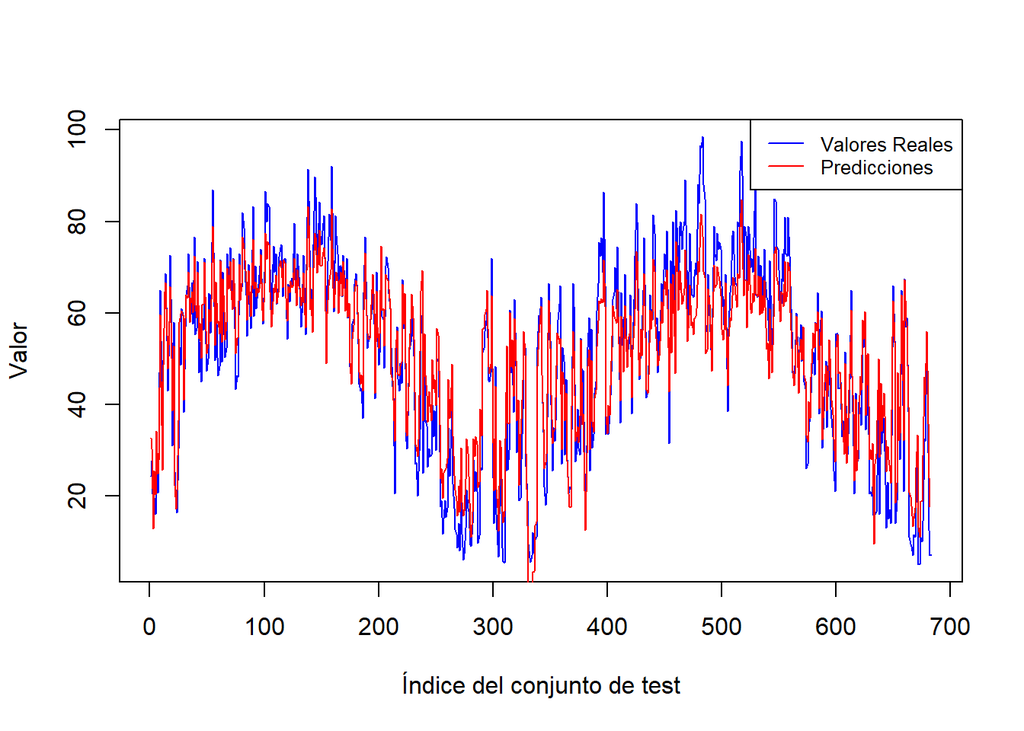

```r
predicciones <- c()
for (i in 1:nrow(dt_test)){
  ev <- f_dt_test[i, .SD, .SDcols = grep("t_1$", colnames(f_dt_test), value = TRUE)]
  pred <- (dbnR::mvn_inference(attr(fit, "mu"), attr(fit, "sigma"), evidence = ev))$mu_p
  predicciones <- c(predicciones, as.numeric(pred["O3_Z5_t_0",]))  }


# Gráfico base con valores reales
plot(dt_test$O3_Z5, type = "l", col = "blue", xlab = "Índice del conjunto de test", ylab = "Valor")

# Añadir la línea de predicciones en el mismo gráfico
lines(predicciones, col = "red")

legend("topright", legend = c("Valores Reales", "Predicciones"), col = c("blue", "red"),
       lty = 1, cex = 0.8)
```

## 1. Cambios por contaminante de atras hacia delante

De atrás hacia delante: he cambiado el valor de la variable “NO2_Z1_t1”, he fijado el resto del instante t1 y he mirado el cambio en la variable “NO2_Z1_t0”.

```r
big_med <- function(datos, numero) {
  # Calcular los cuartiles y la mediana
  Q1 <- quantile(datos, 0.25)
  Q3 <- quantile(datos, 0.75)
  mediana <- median(datos)

  # Calcular el rango intercuartílico (IQR)
  IQR <- Q3 - Q1

  # Calcular los bigotes
  bigote_inferior <- max(min(datos), Q1 - 1.5 * IQR)
  bigote_superior <- min(max(datos), Q3 + 1.5 * IQR)

  # Verificar si el número está dentro del rango intercuartílico
  if (numero >= Q1 & numero <= Q3) {
    return(c(bigote_inferior, bigote_superior))
  } else {
    return(mediana)
  }
}
```

```r
t1_vars <- grep("t_1$", colnames(f_dt_test), value = TRUE)
var <- "NO2_Z1_t_1"
t1_vars <- t1_vars[t1_vars != var]

# Obtener el nombre de la columna correspondiente "t_0"
var_t0 <- sub("t_1$", "t_0", var)

ev_vars <- c(var, t1_vars)
ev <- f_dt_test[1, .SD, .SDcols = ev_vars]

pred <- dbnR::mvn_inference(attr(fit, "mu"), attr(fit, "sigma"), evidence = ev)


# Realizar la intervención
ev_i <- f_dt_test[1, .SD, .SDcols = c(var, t1_vars)]
new_value <- big_med(f_dt_test[[var_t0]], ev_i[[var]])

ev_i[1, (var) := new_value]

# Hacer predicción con la intervención
pred_i <- dbnR::mvn_inference(attr(fit, "mu"), attr(fit, "sigma"), ev_i)

# Mostrar los resultados
cat(sprintf("Variable: %s\n", var))
```

```
## Variable: NO2_Z1_t_1
```

```r
cat(sprintf("The previous value for '%s' is %f, and after the modification it changes to %f\n",
            var, f_dt_test[1, get(var)], ev_i[1, get(var)]))
```

```
## The previous value for 'NO2_Z1_t_1' is 39.333333, and after the modification it changes to 26.266667
```

```r
cat(sprintf("The prediction for '%s' is %f, and after the modification it changes to %f\n",
            var_t0, pred$mu_p[var_t0,], pred_i$mu_p[var_t0,]))
```

```
## The prediction for 'NO2_Z1_t_0' is 39.649652, and after the modification it changes to 32.774126
```

### 1.1. Test de hipótesis

```r
n_test <- 6
vals_test <- data.frame(original = c(), modificado = c())
for (i in 1:n_test){
  ev <- f_dt_test[i, .SD, .SDcols = ev_vars]

  pred <- dbnR::mvn_inference(attr(fit, "mu"), attr(fit, "sigma"), evidence = ev)

  # Realizar la intervención
  ev_i <- f_dt_test[i, .SD, .SDcols = ev_vars]
  new_value <- big_med(f_dt_test[[var_t0]], ev_i[[var]])

  ev_i[1, (var) := new_value]

  # Hacer predicción con la intervención
  pred_i <- dbnR::mvn_inference(attr(fit, "mu"), attr(fit, "sigma"), ev_i)

  vals_test <- rbind(vals_test, data.frame(original = pred$mu_p[var_t0,],
                                           modificado = pred_i$mu_p[var_t0,]))
}

print(vals_test)
```

```
##             original modificado
## NO2_Z1_t_0  39.64965   32.77413
## NO2_Z1_t_01 46.06775   32.96566
## NO2_Z1_t_02 62.11819   37.26456
## NO2_Z1_t_03 54.12939   34.44995
## NO2_Z1_t_04 56.76891   36.21249
## NO2_Z1_t_05 47.00912   33.73164
```

#### 1.1.1. Pruebas de variabilidad

```r
# 1. Prueba F de varianzas (F-test)
resultado_ftest <- var.test(vals_test$original, vals_test$modificado)
cat("Prueba F de varianzas (F-test)")
```

```
## Prueba F de varianzas (F-test)
```

```r
print(resultado_ftest)
```

```
##
##  F test to compare two variances
##
## data:  vals_test$original and vals_test$modificado
## F = 20.38, num df = 5, denom df = 5, p-value = 0.004885
## alternative hypothesis: true ratio of variances is not equal to 1
## 95 percent confidence interval:
##    2.851855 145.646418
## sample estimates:
## ratio of variances
##           20.38044
```

```r
cat("El p-valor es menor que 0.05, lo que indica que hay una diferencia significativa entre las varianzas de los dos vectores.\n\n")
```

```
## El p-valor es menor que 0.05, lo que indica que hay una diferencia significativa entre las varianzas de los dos vectores.
```

```r
# 2. Prueba de Levene
# Instalar y cargar el paquete car si no lo tienes
if (!require(car)) install.packages("car")
library(car)

# Combinar los vectores en un data frame
data_levene <- data.frame(
  valores = c(vals_test$original, vals_test$modificado),
  grupo = factor(rep(c("original", "modificado"), each = nrow(vals_test)))
)

# Realizar la prueba de Levene
resultado_levene <- leveneTest(valores ~ grupo, data = data_levene)
cat("\n Prueba de Levene")
```

```
##
##  Prueba de Levene
```

```r
print(resultado_levene)
```

```
## Levene's Test for Homogeneity of Variance (center = median)
##       Df F value   Pr(>F)
## group  1  11.724 0.006503 **
##       10
## ---
## Signif. codes:  0 '***' 0.001 '**' 0.01 '*' 0.05 '.' 0.1 ' ' 1
```

```r
cat("El p-valor es menor que 0.05, lo que sugiere que las varianzas de los dos vectores son significativamente diferentes.\n\n")
```

```
## El p-valor es menor que 0.05, lo que sugiere que las varianzas de los dos vectores son significativamente diferentes.
```

```r
# 3. Prueba de Bartlett
resultado_bartlett <- bartlett.test(list(vals_test$original, vals_test$modificado))
cat("\n Prueba de Bartlett")
```

```
##
##  Prueba de Bartlett
```

```r
print(resultado_bartlett)
```

```
##
##  Bartlett test of homogeneity of variances
##
## data:  list(vals_test$original, vals_test$modificado)
## Bartlett's K-squared = 7.8367, df = 1, p-value = 0.005119
```

```r
cat("El p-valor es menor que 0.05, lo que sugiere que las varianzas de los dos vectores son significativamente diferentes.")
```

```
## El p-valor es menor que 0.05, lo que sugiere que las varianzas de los dos vectores son significativamente diferentes.
```

### 1.3. Cambio en t2

```r
t1_vars <- grep("t_1$", colnames(f_dt_test), value = TRUE)
var <- "NO2_Z1_t_1"
t1_vars <- t1_vars[t1_vars != var]

# Obtener el nombre de la columna correspondiente "t_0"
var_t0 <- sub("t_1$", "t_0", var)

ev_vars <- c(var, t1_vars)
ev <- f_dt_test[2, .SD, .SDcols = ev_vars]

pred2 <- dbnR::mvn_inference(attr(fit, "mu"), attr(fit, "sigma"), evidence = ev)


# Realizar la intervención
ev_2i <- f_dt_test[2, .SD, .SDcols = c(var, t1_vars)]

ev_2i[1, (var) := pred_i$mu_p[var_t0,]]

# Hacer predicción con la intervención
pred_2i <- dbnR::mvn_inference(attr(fit, "mu"), attr(fit, "sigma"), ev_2i)

# Mostrar los resultados
cat(sprintf("Variable: %s\n\n", var))
```

```
## Variable: NO2_Z1_t_1
```

```r
cat(sprintf("Con el cambio total, la predicción original de la variable pasa de ser %f y a tomar el valor: %f\n", pred2$mu_p[var_t0,], pred_2i$mu_p[var_t0,]))
```

```
## Con el cambio total, la predicción original de la variable pasa de ser 46.067751 y a tomar el valor: 36.893645
```

### 1.4. Cómo han de ser los valores pasados para bajar x puntos los valores futuros.

```r
t1_vars <- grep("t_1$", colnames(f_dt_test), value = TRUE)
var <- "PM10_Z3_t_1"
t1_vars <- t1_vars[t1_vars != var]

# Obtener el nombre de la columna correspondiente "t_0"
var_t0 <- sub("t_1$", "t_0", var)

ev_vars <- c(var, t1_vars)  # colnames(f_dt_test)[colnames(f_dt_test) != var_t0]
ev <- f_dt_test[1, .SD, .SDcols = ev_vars]

pred <- dbnR::mvn_inference(attr(fit, "mu"), attr(fit, "sigma"), evidence = ev)

# Comprobar si la columna correspondiente "t_0" existe en f_dt_test
if (var_t0 %in% colnames(f_dt_test)) {

  # Realizar la intervención
  ev_i <- f_dt_test[1, .SD, .SDcols = c(var, t1_vars)]
  new_value <- ev_i[[var]]-10

  ev_i[1, (var) := new_value]

  # Hacer predicción con la intervención
  pred_i <- dbnR::mvn_inference(attr(fit, "mu"), attr(fit, "sigma"), ev_i)

  # Mostrar los resultados
  cat(sprintf("Variable: %s\n", var))
  cat(sprintf("The previous value for '%s' is %f, and after the modification it changes to %f\n",
            var, f_dt_test[1, get(var)], ev_i[1, get(var)]))
  cat(sprintf("The prediction for '%s' is %f, and after the modification it changes to %f\n\n",
            var_t0, pred$mu_p[var_t0,], pred_i$mu_p[var_t0,]))}
```

```
## Variable: PM10_Z3_t_1
## The previous value for 'PM10_Z3_t_1' is 11.000000, and after the modification it changes to 1.000000
## The prediction for 'PM10_Z3_t_0' is 13.427232, and after the modification it changes to 12.815972
```

## 2. Cambios por contaminante de delante hacia atras

De delante hacia atrás: he cambiado el valor de la variable “NO2_Z1_t0”, he fijado el resto del instante t0 y he mirado el cambio en la variable “NO2_Z1_t1”.

```r
t0_vars <- grep("t_0$", colnames(f_dt_test), value = TRUE)
var <- "NO2_Z1_t_0"
t0_vars <- t0_vars[t0_vars != var]

# Obtener el nombre de la columna correspondiente "t_0"
var_t1 <- sub("t_0$", "t_1", var)

ev_vars <- c(var, t0_vars)
ev <- f_dt_test[1, .SD, .SDcols = ev_vars]

pred <- dbnR::mvn_inference(attr(fit, "mu"), attr(fit, "sigma"), evidence = ev)


# Realizar la intervención
ev_i <- f_dt_test[1, .SD, .SDcols = ev_vars]
new_value <- big_med(f_dt_test[[var_t1]], ev_i[[var]])

ev_i[1, (var) := new_value]

# Hacer predicción con la intervención
pred_i <- dbnR::mvn_inference(attr(fit, "mu"), attr(fit, "sigma"), ev_i)

# Mostrar los resultados
cat(sprintf("Variable: %s\n", var))
```

```
## Variable: NO2_Z1_t_0
```

```r
cat(sprintf("The previous value for '%s' is %f, and after the modification it changes to %f\n",
            var, f_dt_test[1, get(var)], ev_i[1, get(var)]))
```

```
## The previous value for 'NO2_Z1_t_0' is 51.166667, and after the modification it changes to 26.266667
```

```r
cat(sprintf("The previous value for '%s' is %f, and after the modification it changes to %f\n",
            var_t1, pred$mu_p[var_t1,], pred_i$mu_p[var_t1,]))
```

```
## The previous value for 'NO2_Z1_t_1' is 55.470862, and after the modification it changes to 32.334940
```

### 2.1. Test de hipótesis

```r
n_test <- 6
vals_test <- data.frame(original = c(), modificado = c())
for (i in 1:n_test){
  ev <- f_dt_test[i, .SD, .SDcols = ev_vars]

  pred <- dbnR::mvn_inference(attr(fit, "mu"), attr(fit, "sigma"), evidence = ev)

  # Realizar la intervención
  ev_i <- f_dt_test[i, .SD, .SDcols = ev_vars]
  new_value <- big_med(f_dt_test[[var_t0]], ev_i[[var]])

  ev_i[1, (var) := new_value]

  # Hacer predicción con la intervención
  pred_i <- dbnR::mvn_inference(attr(fit, "mu"), attr(fit, "sigma"), ev_i)

  vals_test <- rbind(vals_test, data.frame(original = pred$mu_p[var_t1,], modificado =
                                             pred_i$mu_p[var_t1,]))
}

print(vals_test)
```

```
##             original modificado
## NO2_Z1_t_1  55.47086  22.795631
## NO2_Z1_t_11 68.82924  15.402915
## NO2_Z1_t_12 52.94963   8.659984
## NO2_Z1_t_13 61.17453  15.336294
## NO2_Z1_t_14 46.89078  13.905827
## NO2_Z1_t_15 60.46824  18.036899
```

## 3. Comparacion de modelo con zonas colindantes con modelo con zonas no colindantes.

```r
#Modelo con zonas colindantes para la zona 3
ev_vars_col <- names(f_dt_test)[grepl("Z2_t_1|Z4_t_1$", names(f_dt_test))] #t_1 solo porque se fijan las variables del pasado
ev_col <- f_dt_test[1, .SD, .SDcols = ev_vars_col]

pred_col <- (dbnR::mvn_inference(attr(fit, "mu"), attr(fit, "sigma"), evidence = ev_col))$mu_p

pred_col_Z3 <- data.frame(t(pred_col[grep("Z3_t_0", rownames(pred_col)), , drop = FALSE])) #t_0 solo porque nos interesan las variables del futuro
real_Z3 <- data.frame(f_dt_test[1, .SD, .SDcols = names(f_dt_test)[grep("Z3_t_0", names(f_dt_test))], , drop = FALSE])

# Definir el orden de las columnas por las que se desea ordenar
columnas_orden <- names(real_Z3)  # Utilizamos las columnas de real_Z3 para ordenar

# Ordenar pred_col_Z3 por las mismas columnas que en real_Z3
pred_col_Z3 <- pred_col_Z3 %>% select(all_of(columnas_orden)) %>% arrange_all()

# Ordenar real_df por las mismas columnas
real_Z3 <- real_Z3 %>% arrange_all()

#Error cuadrático medio
mse_col <- mean((as.numeric(real_Z3) - as.numeric(pred_col_Z3))^2)
print(paste("Mean Squared Error:", mse_col))
```

```
## [1] "Mean Squared Error: 5.8092263365596"
```

```r
#Modelo con zonas no colindantes para la Zona 3
ev_vars_nocol <- names(f_dt_test)[grepl("Z5_t_1$", names(f_dt_test))]
ev_nocol <- f_dt_test[1, .SD, .SDcols = ev_vars_nocol]

pred_nocol <- (dbnR::mvn_inference(attr(fit, "mu"), attr(fit, "sigma"), evidence = ev_nocol))$mu_p

pred_nocol_Z3 <- data.frame(t(pred_nocol[grep("Z3_t_0", rownames(pred_nocol)), , drop = FALSE]))

# Ordenar pred_col_Z3 por las mismas columnas que en real_Z3
pred_col_Z3 <- pred_col_Z3 %>% select(all_of(columnas_orden)) %>% arrange_all()

#Error cuadrático medio
mse_nocol <- mean((as.numeric(real_Z3) - as.numeric(pred_nocol_Z3))^2)
print(paste("Mean Squared Error:", mse_nocol))
```

```
## [1] "Mean Squared Error: 1205.41723875317"
```

## 4. Con valores missings, cómo predigo el futuro.

### 4.1 No se tiene dato de la variable O3 en la Zona 5 pero si en el resto de las zonas

```r
missing_1 <- "O3_Z5_t_1"
ev_1 <- f_dt_test[1, .SD, .SDcols = setdiff(names(f_dt_test)[grepl("t_1$", names(f_dt_test))], missing_1)]

pred_1 <- (dbnR::mvn_inference(attr(fit, "mu"), attr(fit, "sigma"), evidence = ev_1))$mu_p

pred_missing_1 <- pred_1[grep("^O3_Z5", colnames(f_dt_test), value=TRUE),]
real_missing_1 <- data.frame(f_dt_test[1, .SD, .SDcols = grep("^O3_Z5", colnames(f_dt_test))])

#Error cuadrático medio de predicción
mse_missing_pred_1 <- mean((as.numeric(real_missing_1[1,1]) - as.numeric(pred_missing_1[1]))^2)
print(paste("Mean Squared Error of Prediction:", mse_missing_pred_1))
```

```
## [1] "Mean Squared Error of Prediction: 26.7331878415171"
```

```r
#Error cuadrático medio del missing
mse_missing_1 <- mean((as.numeric(real_missing_1[missing_1]) - as.numeric(pred_missing_1[missing_1]))^2)
print(paste("Mean Squared Error of Missing Value:", mse_missing_1))
```

```
## [1] "Mean Squared Error of Missing Value: 5.47854165083423"
```

### 4.2. No se tiene dato de la variable O3 en ninguna zona pero si del resto de contaminantes

```r
missing_2 <- names(f_dt_test)[grepl("^O3.*t_1$", names(f_dt_test))]
ev_2 <- f_dt_test[1, .SD, .SDcols = setdiff(names(f_dt_test)[grepl("t_1$", names(f_dt_test))], missing_2)]

pred_2 <- (dbnR::mvn_inference(attr(fit, "mu"), attr(fit, "sigma"), evidence = ev_2))$mu_p

pred_missing_2 <- pred_2[grep("^O3", colnames(f_dt_test), value=TRUE),]
real_missing_2 <- data.frame(f_dt_test[1, .SD, .SDcols = grep("^O3", colnames(f_dt_test))])

#Error cuadrático medio de predicción
mse_missing_pred_2 <- mean((as.numeric(real_missing_2["O3_Z5_t_0"]) - as.numeric(pred_missing_2["O3_Z5_t_0"]))^2)
print(paste("Mean Squared Error of Prediction:", mse_missing_pred_2))
```

```
## [1] "Mean Squared Error of Prediction: 149.97510080916"
```

```r
#Error cuadrático medio del missing
mse_missing_2 <- mean((as.numeric(real_missing_2[missing_2]) - as.numeric(pred_missing_2[missing_2]))^2)
print(paste("Mean Squared Error of Missing Value:", mse_missing_2))
```

```
## [1] "Mean Squared Error of Missing Value: 123.53611090016"
```

### 4.3. Se tiene todo

```r
ev_3 <- f_dt_test[1, .SD, .SDcols = names(f_dt_test)[grepl("t_1$", names(f_dt_test))]]

pred_3 <- (dbnR::mvn_inference(attr(fit, "mu"), attr(fit, "sigma"), evidence = ev_3))$mu_p

pred_missing_3 <- pred_3["O3_Z5_t_0",]
real_missing_3 <- data.frame(f_dt_test[1, .SD, .SDcols = "O3_Z5_t_0"])

#Error cuadrático medio de predicción
mse_missing_pred_3 <- mean((as.numeric(real_missing_3) - as.numeric(pred_missing_3))^2)
print(paste("Mean Squared Error of Prediction:", mse_missing_pred_3))
```

```
## [1] "Mean Squared Error of Prediction: 24.3515214451965"
```

El error de prediccion no varia mucho del modelo con todos los datos al modelo con los datos del resto de las zonas

## 5. Variabilidad de los resultados al variar los valores de las evidencias.

```r
var <- "NO2_Z1_t_0"

#Datos de la variable "NO2_Z1"
NO2_Z1 <- df_multiv$NO2_Z1

# Media y desviación estándar de los datos
media <- mean(NO2_Z1)
sd <- sd(NO2_Z1)

# Generar valores aleatorios
set.seed(123)  # Fijar la semilla para reproducibilidad
n <- 15  # Número de valores a generar
valores <- rnorm(n, mean = media, sd = sd)


vals_test <- data.frame(original = c(), modificado = c())
for (i in 1:n){
  ev_vars <- c(var, t0_vars)
  ev <- f_dt_test[i, .SD, .SDcols = ev_vars]

  pred <- dbnR::mvn_inference(attr(fit, "mu"), attr(fit, "sigma"), evidence = ev)

  # Realizar la intervención
  ev_i <- f_dt_test[i, .SD, .SDcols = ev_vars]
  ev_i[1, (var) := valores[i]]

  # Hacer predicción con la intervención
  pred_i <- dbnR::mvn_inference(attr(fit, "mu"), attr(fit, "sigma"), ev_i)

  # Mostrar los resultados
  cat(sprintf("Variable: %s\n", var))
  cat(sprintf("The previous value for '%s' is %f, and after the modification it changes to %f\n",
            var, f_dt_test[1, get(var)], ev_i[1, get(var)]))
  cat(sprintf("The previous value for '%s' is %f, and after the modification it changes to %f\n",
            var_t1, pred$mu_p[var_t1,], pred_i$mu_p[var_t1,]))

  vals_test <- rbind(vals_test, data.frame(original = pred$mu_p[var_t1,], modificado =
                                             pred_i$mu_p[var_t1,]))
}
```

```
## Variable: NO2_Z1_t_0
## The previous value for 'NO2_Z1_t_0' is 51.166667, and after the modification it changes to 32.267715
## The previous value for 'NO2_Z1_t_1' is 55.470862, and after the modification it changes to 37.910835
## Variable: NO2_Z1_t_0
## The previous value for 'NO2_Z1_t_0' is 51.166667, and after the modification it changes to 38.244857
## The previous value for 'NO2_Z1_t_1' is 68.829240, and after the modification it changes to 36.071801
## Variable: NO2_Z1_t_0
## The previous value for 'NO2_Z1_t_0' is 51.166667, and after the modification it changes to 70.616892
## The previous value for 'NO2_Z1_t_1' is 52.949634, and after the modification it changes to 59.407460
## Variable: NO2_Z1_t_0
## The previous value for 'NO2_Z1_t_0' is 51.166667, and after the modification it changes to 43.686129
## The previous value for 'NO2_Z1_t_1' is 61.174533, and after the modification it changes to 41.060957
## Variable: NO2_Z1_t_0
## The previous value for 'NO2_Z1_t_0' is 51.166667, and after the modification it changes to 44.749811
## The previous value for 'NO2_Z1_t_1' is 46.890776, and after the modification it changes to 40.618814
## Variable: NO2_Z1_t_0
## The previous value for 'NO2_Z1_t_0' is 51.166667, and after the modification it changes to 73.446354
## The previous value for 'NO2_Z1_t_1' is 60.468241, and after the modification it changes to 71.413378
## Variable: NO2_Z1_t_0
## The previous value for 'NO2_Z1_t_0' is 51.166667, and after the modification it changes to 50.751027
## The previous value for 'NO2_Z1_t_1' is 66.140702, and after the modification it changes to 62.037895
## Variable: NO2_Z1_t_0
## The previous value for 'NO2_Z1_t_0' is 51.166667, and after the modification it changes to 19.517394
## The previous value for 'NO2_Z1_t_1' is 41.694423, and after the modification it changes to 32.728767
## Variable: NO2_Z1_t_0
## The previous value for 'NO2_Z1_t_0' is 51.166667, and after the modification it changes to 29.980768
## The previous value for 'NO2_Z1_t_1' is 62.742724, and after the modification it changes to 62.105419
## Variable: NO2_Z1_t_0
## The previous value for 'NO2_Z1_t_0' is 51.166667, and after the modification it changes to 34.345407
## The previous value for 'NO2_Z1_t_1' is 65.828086, and after the modification it changes to 46.946516
## Variable: NO2_Z1_t_0
## The previous value for 'NO2_Z1_t_0' is 51.166667, and after the modification it changes to 64.561424
## The previous value for 'NO2_Z1_t_1' is 36.601109, and after the modification it changes to 72.244760
## Variable: NO2_Z1_t_0
## The previous value for 'NO2_Z1_t_0' is 51.166667, and after the modification it changes to 48.921458
## The previous value for 'NO2_Z1_t_1' is 19.827024, and after the modification it changes to 51.159434
## Variable: NO2_Z1_t_0
## The previous value for 'NO2_Z1_t_0' is 51.166667, and after the modification it changes to 49.662635
## The previous value for 'NO2_Z1_t_1' is 23.572121, and after the modification it changes to 51.319092
## Variable: NO2_Z1_t_0
## The previous value for 'NO2_Z1_t_0' is 51.166667, and after the modification it changes to 44.413131
## The previous value for 'NO2_Z1_t_1' is 38.247981, and after the modification it changes to 54.241622
## Variable: NO2_Z1_t_0
## The previous value for 'NO2_Z1_t_0' is 51.166667, and after the modification it changes to 32.351582
## The previous value for 'NO2_Z1_t_1' is 51.424764, and after the modification it changes to 56.768866
```

```r
print(vals_test)
```

```
##              original modificado
## NO2_Z1_t_1   55.47086   37.91084
## NO2_Z1_t_11  68.82924   36.07180
## NO2_Z1_t_12  52.94963   59.40746
## NO2_Z1_t_13  61.17453   41.06096
## NO2_Z1_t_14  46.89078   40.61881
## NO2_Z1_t_15  60.46824   71.41338
## NO2_Z1_t_16  66.14070   62.03790
## NO2_Z1_t_17  41.69442   32.72877
## NO2_Z1_t_18  62.74272   62.10542
## NO2_Z1_t_19  65.82809   46.94652
## NO2_Z1_t_110 36.60111   72.24476
## NO2_Z1_t_111 19.82702   51.15943
## NO2_Z1_t_112 23.57212   51.31909
## NO2_Z1_t_113 38.24798   54.24162
## NO2_Z1_t_114 51.42476   56.76887
```

#### 5.1. Pruebas de variabilidad

```r
# 1. Prueba F de varianzas (F-test)
resultado_ftest <- var.test(vals_test$original, vals_test$modificado)
cat("Prueba F de varianzas (F-test)")
```

```
## Prueba F de varianzas (F-test)
```

```r
print(resultado_ftest)
```

```
##
##  F test to compare two variances
##
## data:  vals_test$original and vals_test$modificado
## F = 1.5239, num df = 14, denom df = 14, p-value = 0.4404
## alternative hypothesis: true ratio of variances is not equal to 1
## 95 percent confidence interval:
##  0.5116283 4.5391583
## sample estimates:
## ratio of variances
##            1.52393
```

```r
cat("El p-valor es mayor que 0.05, lo que indica que no hay diferencia significativa entre las varianzas de los dos vectores y, por lo tanto, los cambios en las predicciones no tienen que ver con el cambio en las evidencias si no con el resto de variables.\n\n")
```

```
## El p-valor es mayor que 0.05, lo que indica que no hay diferencia significativa entre las varianzas de los dos vectores y, por lo tanto, los cambios en las predicciones no tienen que ver con el cambio en las evidencias si no con el resto de variables.
```

```r
# 2. Prueba de Levene
# Instalar y cargar el paquete car si no lo tienes
if (!require(car)) install.packages("car")
library(car)

# Combinar los vectores en un data frame
data_levene <- data.frame(
  valores = c(vals_test$original, vals_test$modificado),
  grupo = factor(rep(c("original", "modificado"), each = nrow(vals_test)))
)

# Realizar la prueba de Levene
resultado_levene <- leveneTest(valores ~ grupo, data = data_levene)
cat("\n Prueba de Levene")
```

```
##
##  Prueba de Levene
```

```r
print(resultado_levene)
```

```
## Levene's Test for Homogeneity of Variance (center = median)
##       Df F value Pr(>F)
## group  1  0.4751 0.4963
##       28
```

```r
cat("El p-valor es mayor que 0.05, lo que sugiere que las varianzas de los dos vectores no son significativamente diferentes y, por lo tanto, los cambios en las predicciones no tienen que ver con el cambio en las evidencias si no con el resto de variables.\n\n")
```

```
## El p-valor es mayor que 0.05, lo que sugiere que las varianzas de los dos vectores no son significativamente diferentes y, por lo tanto, los cambios en las predicciones no tienen que ver con el cambio en las evidencias si no con el resto de variables.
```

```r
# 3. Prueba de Bartlett
resultado_bartlett <- bartlett.test(list(vals_test$original, vals_test$modificado))
cat("\n Prueba de Bartlett")
```

```
##
##  Prueba de Bartlett
```

```r
print(resultado_bartlett)
```

```
##
##  Bartlett test of homogeneity of variances
##
## data:  list(vals_test$original, vals_test$modificado)
## Bartlett's K-squared = 0.5954, df = 1, p-value = 0.4403
```

```r
cat("El p-valor es mayor que 0.05, lo que sugiere que las varianzas de los dos vectores no son significativamente diferentes y, por lo tanto, los cambios en las predicciones no tienen que ver con el cambio en las evidencias si no con el resto de variables.")
```

```
## El p-valor es mayor que 0.05, lo que sugiere que las varianzas de los dos vectores no son significativamente diferentes y, por lo tanto, los cambios en las predicciones no tienen que ver con el cambio en las evidencias si no con el resto de variables.
```